# STA 506 Final Examination

Josie Gallop Spring 2026

Due: May 5, 2026

## **Final Exam Guidelines**

- **Coverage**: The major concepts and inference procedures—such as sampling distributions, confidence intervals, and hypothesis testing—are covered and implemented using both classical parametric likelihood-based methods and modern non-parametric approaches, including the bootstrap and kernel density estimation.
- **Part A** requires derivation of selected likelihood-based functions for performing various types of inference, with sufficient detail to enable translation of these derivations into code for numerical analysis.
- Your code for the problems in **Part B** must align with your derivations in **Part A** and be well commented where necessary.
- In **Part B**, all numerical results must be interpreted from a practical perspective.

## **Policies of Using AI Tools**

- **Policy on AI Tool Use**: Students must adhere to the AI tool policy specified in the course syllabus. The direct copying of AI-generated content is strictly prohibited. All submitted work must reflect your own understanding; where external tools are consulted, content must be thoroughly rephrased and synthesized in your own words.
- **Code Inclusion Requirement**: Any code included in your essay must be properly commented to explain the purpose and/or expected output of key code lines. Submitting AI-generated code without meaningful, student-added comments will not be accepted.

## **Working Model for the Final Exam**

**Caution**: *Please follow the suggested expressions and guided steps to complete the exam. Other approaches such as transformation for trivialize the problems that will not meet the exam objectives.*

The **Kumaraswamy distribution** is a two-parameter continuous probability distribution defined on the interval (0, 1). It is often used as an alternative to the Beta distribution due to its simple closed-form expressions for the cumulative distribution function (CDF) and quantile function. It is commonly used in

- **Hydrology**: Modeling rainfall, streamflow, or other bounded natural phenomena
- **Economics**: Income shares, proportions, or bounded indices
- **Monte Carlo simulation**: Efficient random variate generation (via inverse transform)
- **Machine learning**: Output layer for bounded targets, prior distributions in Bayesian models
- **Reliability engineering**: Modeling failure rates of systems with bounded lifetimes

Let $X$ be the Kumaraswamy random variable with Cumulative Distribution Function (CDF)

$$F(x; a, b) = 1 - (1 - x^a)^b$$

where $a > 0$ and $b > 0$ unknown parameters and $0 < x < 1$.

The following are two special case of the Kumaraswamy distribution:

1. **Uniform Distribution**: When $a = 1$ and $b = 1$, the Kumaraswamy distribution becomes a uniform distribution over $[0, 1]$ with CDF $F(x) = x$.
2. **Power Distribution**: when $b = 1$ and $a > 0$, the Kumaraswamy distribution becomes a power distribution over $[0, 1]$ with CDF $F(x) = x^a$.

This final exam focuses on inferences of Kumaraswamy distribution and related data analysis.

## Part A: Methodological Derivations

### **Problem A1**:

Show that the density function of the Kumaraswamy distribution is

$$f(x; a, b) = ab \, x^{a-1} (1 - x^a)^{b-1}.$$

To begin, we are given that the CDF for the Kumaraswamy distribution is $F(x; a, b) = 1 - (1 - x^a)^b$. To get the density function, I will take the derivative of the CDF with respect to x.

By taking the derivative with use of the chain rule, this results in $f(x;a,b) = - b(1 - x^a)^{b-1} \cdot (-a x^{a-1})$.

Simplifying this results in $f(x;a,b) = ab\,x^{a-1}(1 - x^a)^{b-1}$

Therefore this proves that the density function for the Kumaraswamy distribution is $f(x; a, b) = ab \, x^{a-1} (1 - x^a)^{b-1}$.

### **Problem A2**:

Let $\{x_1, x_2, \cdots, x_n \}$ be an i.i.d. random sample taken from a population that follows the aove 2-parameter Kumaraswamy distribution. Write out the loglikelihood function of $a$ and $b$, denoted by $\ell(a,b)$, based on the above random sample and **derive** the gradient vector $[\ell_a^\prime(a,b), \ell_b^\prime(a,b)]$, the first order partial derivative of the log-likelihood with respect to parameters $a$ and $b$.

I will find the log-likelihood function for the Kumaraswamy distribution, dentore as $\ell(a,b)$. Then, I will use this log-likelihood function to derive the gradient functions for a and b, denoted by $\ell_a^\prime(a,b)$ and $\ell_b^\prime(a,b)]$ respectively. I will find these gradients by taking the first order partial derivative of the log-likelihood function with respect to parameters $a$ and $b$. I will report these gradient functions for parameters $a$ and $b$ as the gradient vector, $[\ell_a^\prime(a,b), \ell_b^\prime(a,b)]$.

The likelihood function is as follows $L(a,b) = \prod_{i=1}^n ab\, x_i^{a-1}(1 - x_i^a)^{b-1}$.

In order to get the log-likelihood function, I will take the derivative of the likelihood function $L(a,b)$. This results in $\ell(a,b) = n\log a + n\log b + (a-1)\sum_{i=1}^n \log x_i + (b-1)\sum_{i=1}^n \log(1 - x_i^a)$.

Therefore the log-likelihood function is $\ell(a,b) = n\log a + n\log b + (a-1)\sum_{i=1}^n \log x_i + (b-1)\sum_{i=1}^n \log(1 - x_i^a)$.

Next, the gradient functions for parameters $a$ and $b$ will be found. These will be found with taking the first order partial derivatives of the log-likelihood function with respect to $a$ and $b$. I will begin with the gradient function for $a$.

$\frac{\partial \ell}{\partial a} = \frac{n}{a} + \sum_{i=1}^n \log x_i + (b-1)\sum_{i=1}^n \frac{-x_i^a \log x_i}{1 - x_i^a}$

Simplifying this gives the gradient function for $a$: $\frac{\partial \ell}{\partial a} = \frac{n}{a} + \sum_{i=1}^n \log x_i - (b-1)\sum_{i=1}^n \frac{x_i^a \log x_i}{1 - x_i^a}$

Now, I will find the gradient function for $b$. I will take the partial derivative of the log-likelihood function with respect to parametere $b$ this time.

$\frac{\partial \ell}{\partial b} = \frac{n}{b} + \sum_{i=1}^n \log(1 - x_i^a)$.

Therefore, this is the gradient function for parameter $b$.

Altogether, the gradient vector $[\ell_a^\prime(a,b), \ell_b^\prime(a,b)]$ is:

$= \left[\frac{n}{a} + \sum_{i=1}^n \log x_i - (b-1)\sum_{i=1}^n \frac{x_i^a \log x_i}{1 - x_i^a} , \frac{n}{b} + \sum_{i=1}^n \log(1 - x_i^a)\right]$

### **Problem A3**:

Based on the gradients functions obtained in the above problem A2, **derive** the observed Fisher Information matrix (i.e, the negative Hessian Matrix).

Now, I will find the observed Fisher Information matrix using the gradient functions I found for parameters $a$ and $b$ in the previous part. I will do so by taking the second derivatives with respect to the parameters. I will begin by taking the second derivative with respect to $a$.

$\frac{\partial^2 \ell}{\partial a^2}=\frac{d}{da}\left(\frac{n}{a}\right)+\frac{d}{da}\left(\sum \log x_i\right)-(b-1)\frac{d}{da}\left(\sum \frac{x_i^a \log x_i}{1-x_i^a}\right)$

Going through each part:

$\frac{d}{da}\left(\frac{n}{a}\right)=-\frac{n}{a^2}$

$\frac{d}{da}\left(\sum \log x_i\right)=0$

For the last part, I applied the quotient rule. $\frac{d}{da}\left(\sum \frac{x_i^a \log x_i}{1-x_i^a}\right)$ = $=\frac{x_i^a (\log x_i)^2(1-x_i^a) - (x_i^a \log x_i)(-x_i^a \log x_i)}{(1-x_i^a)^2}$ = $\frac{d}{da}\left(\frac{x_i^a \log x_i}{1-x_i^a}\right)=\frac{x_i^a (\log x_i)^2}{(1-x_i^a)^2}$

So altogether, I get: $\frac{\partial^2 \ell}{\partial a^2} = -\frac{n}{a^2} - (b-1)\sum_{i=1}^n \frac{x_i^a (\log x_i)^2 }{(1 - x_i^a)^2}$

Next, I will take the second derivative for parameter $b$. Second derivative w.r.t. $b$: $\frac{\partial^2 \ell}{\partial b^2}=\frac{d}{db}\left(\frac{n}{b}+\sum \log(1-x_i^a)\right)$

The second term turns into zero, so altogether I get: $\frac{\partial^2 \ell}{\partial b^2} = -\frac{n}{b^2}$

Lastly, I will find the mixed derivative. I will take the derivative of the partial for $a$, but differentiate it with respect to $b$. So, $\frac{\partial^2 \ell}{\partial a \partial b}=\frac{\partial}{\partial b}\left[\frac{\partial \ell}{\partial a}\right]$

$\frac{\partial}{\partial b}\left[-(b-1)\sum_{i=1}^n \frac{x_i^a \log x_i}{1-x_i^a}\right]$ $= \sum_{i=1}^n \frac{\partial}{\partial b}\left[-(b-1)\cdot \frac{x_i^a \log x_i}{1-x_i^a}\right]$ = $\frac{\partial^2 \ell}{\partial a \partial b}=\sum_{i=1}^n \frac{x_i^a \log x_i}{1-x_i^a} * -1$

So altogether this gets: $\frac{\partial^2 \ell}{\partial a \partial b} = -\sum_{i=1}^n \frac{x_i^a \log x_i}{1 - x_i^a}$.

Next, I will find the other mixed derivative. This time I will take the partial I found with respect to $b$ and differentiate it with respect to $a$. $\frac{\partial \ell}{\partial b}=\frac{n}{b}+\sum_{i=1}^n \log(1-x_i^a)$

$\frac{\partial}{\partial a}\left[\sum_{i=1}^n \log(1-x_i^a)\right]$ $= \sum_{i=1}^n \frac{1}{1-x_i^a}\cdot \frac{\partial}{\partial a}(1-x_i^a)$

$\frac{\partial}{\partial a}(1-x_i^a)=-x_i^a \log x_i$

Altogether this gets, $\frac{\partial^2 \ell}{\partial b \partial a}=-\sum_{i=1}^n \frac{x_i^a \log x_i}{1-x_i^a}$

The two mixed derivatives end up being the same results.

Finally, I will put these all together in the Fisher Information Matrix. $I(a,b) = -H(a,b)$

$I(a,b) = - \begin{bmatrix}\frac{\partial^2 \ell}{\partial a^2} & \frac{\partial^2 \ell}{\partial a \partial b} \\\frac{\partial^2 \ell}{\partial b \partial a} & \frac{\partial^2 \ell}{\partial b^2}\end{bmatrix}$

Plugging in the found derivatives, I get the final Fisher Information matrix.

$I(a,b)=\begin{bmatrix}\frac{n}{a^2}+(b-1)\sum \frac{x_i^a (\log x_i)^2}{(1-x_i^a)^2}&\sum \frac{x_i^a \log x_i}{1-x_i^a}\\\sum \frac{x_i^a \log x_i}{1-x_i^a}&\frac{n}{b^2}\end{bmatrix}$

### **Problem A4**:

Consider power distribution $F(x) = x^a, (a >0 \quad \text{ and }\quad x \in (0,1))$, a special case of the Kumaraswamy distribution with $b = 1$, and a random sample from this distribution $\{ x_1, x_2, \cdots, x_n\}$. **Derive** the MLE and MME of $a$ respectively. [*Hint: To find the MME, you need to compute the moment of the power distribution; that is, $E[X^k] = \int_0^1 x^k F'(x) dx$. Note that both the MLE and the MME have closed-form expressions.*]

I will consider the Power distribution, $F(x) = x^a, (a >0 \quad \text{ and }\quad x \in (0,1))$. This is a special case of the Kumaraswamy distribution with b = 1. I will find the MLE and MME of parameter $a$.

First, I will find the density function, f(x), by taking the derivative of F(x). $f(x)=\frac{d}{dx}x^a$.

The PDF is as follows: $f(x) = a x^{a-1}$.

I will begin with finding the MLE of $a$.

The likelihood function is $L(a)=\prod_{i=1}^n a x_i^{a-1}$. Expanding the product gives $L(a)=a^n \prod_{i=1}^n x_i^{a-1}$.

Next, the log-likelihood function can be found. To begin, $\ell(a)=\log L(a)$. So, $\ell(a)=\log(a^n)+\log\left(\prod x_i^{a-1}\right)$.

$\ell(a)=n\log a+(a-1)\sum_{i=1}^n \log x_i$

I will differentiate with respect to $a$. $\frac{d\ell}{da}=\frac{d}{da}\left[n\log a+(a-1)\sum \log x_i\right]$.

Taking the derivative of each term:

$\frac{d}{da}(n\log a)=\frac{n}{a}$

$\frac{d}{da}\left((a-1)\sum \log x_i\right)=\sum \log x_i$

Putting this all together, $\frac{d\ell}{da}=\frac{n}{a}+\sum_{i=1}^n \log x_i$.

Now, I will set the function equal to zero and solve for $a$. $\frac{n}{a}+\sum \log x_i=0$.

$\frac{n}{a}=-\sum \log x_i$

$a=-\frac{n}{\sum \log x_i}$

So, the MLE for $a$ is: $\hat a_{MLE}=-\frac{n}{\sum \log x_i}$.

Next, I will find the MME for $a$. I will begin by computing the moment of the power distribution. I will find the expected value first. $E[X]=\int_0^1 x f(x) dx$

$E[X]=\int_0^1 x (a x^{a-1}) dx$ $= a \int_0^1 x^a dx$

$\int_0^1 x^a dx = \frac{1}{a+1}$

$E[X]=a \cdot \frac{1}{a+1}=\frac{a}{a+1}$

Next, I will set the sample mean equal to the expectation and solve for $a$ to get the MME. $\bar{x}=\frac{a}{a+1}$.

$\bar{x}(a+1)=a$

$\bar{x}a+\bar{x}=a$

$\bar{x}=a(1-\bar{x})$

$a=\frac{\bar{x}}{1-\bar{x}}$

So, the MME for $a$ is: $\hat a_{MME}=\frac{\bar{x}}{1-\bar{x}}$.

Altogether,

$\hat a_{MLE}=-\frac{n}{\sum_{i=1}^n \log x_i}$

$\hat a_{MME}=\frac{\bar{x}}{1-\bar{x}}$

### **Problem A5**:

Using the same setting as in **Problem A4**, find the asymptotic (Wald) confidence interval for $a$. [*Hint: Compute the Fisher information for $a$, then take its reciprocal to obtain the variance*.]

Next, I will find the asymptotic (Wald) confidence interval for $a$. I will use the same Power distribution from the previous question. I found that the density function of the Power distribution is $f(x) = a x^{a-1}$. Additionally, the log-likelihood function was found to be $\ell(a)=n\log a+(a-1)\sum_{i=1}^n \log x_i$.

From here, I will take the first derivative with respect to the parameter $a$, $\frac{d\ell}{da}=\frac{n}{a}+\sum_{i=1}^n \log x_i$.

Next, I will take the second derivative: $\frac{d^2\ell}{da^2}=\frac{d}{da}\left(\frac{n}{a}+\sum \log x_i\right)$.

$\frac{d}{da}\left(\frac{n}{a}\right)=-\frac{n}{a^2}$ and $\frac{d}{da}\left(\sum \log x_i\right)=0$.

So, the second derivative is $\frac{d^2\ell}{da^2}=-\frac{n}{a^2}$.

Next, I will compute the Fisher Information for $a$. $I(a)=-E\left[\frac{d^2\ell}{da^2}\right]$

$I(a)=-(-\frac{n}{a^2})$

$I(a)=\frac{n}{a^2}$

Therefore, the Fisher Information for $a$ is $I(a)=\frac{n}{a^2}$.

Next, I will obtain the asymptotic variance by taking the reciprocal of the Fisher Information. $\text{Var}(\hat a)=\frac{1}{I(a)}$.

The variance is, $\text{Var}(\hat a)=\frac{a^2}{n}$.

Therefore, the standard error is the square root of this variance. $SE(\hat a)=\sqrt{\text{Var}(\hat a)}=\frac{a}{\sqrt{n}}$.

We can use the MLE of $a$ to estimate this standard error. $SE(\hat a)\approx \frac{\hat a}{\sqrt{n}}$. This is because we do not know the true value of the parameter $a$, so the MLE will give a good approximation.

The asymptotic (Wald) confidence interval is formatted as $\hat a \pm z_{\alpha/2} \cdot SE(\hat a)$. The standard error is substituted in as $\hat a \pm z_{\alpha/2}\frac{\hat a}{\sqrt{n}}$.

$\hat a \pm z_{\alpha/2}\frac{\hat a}{\sqrt{n}}$

Therefore, the asymptotic (Wald) confidence interval is:

$\left(\hat a - z_{\alpha/2}\frac{\hat a}{\sqrt{n}},\;\hat a + z_{\alpha/2}\frac{\hat a}{\sqrt{n}}\right)$

### **Problem A6**:

Using the same setting as in **Problem A4**, perform a likelihood ratio test for the hypothesis $H_0 :a=1$ (i.e., the power distribution reduces to a uniform distribution). [*Hint: Evaluate the log-likelihood function at the maximum likelihood estimate $\hat{a}$ and at $a=1$, then use these values to construct the LRT test statistic.*]

I will perform a likelihood ratio test for the hypothesis $H_0 :a=1$. The hypotheses are as follows:

$H_0: a=1$

$H_1: a\neq 1$

As found before, the MLE of $a$ is $\hat a_{MLE}=-\frac{n}{\sum_{i=1}^n \log x_i}$. Additionally, the log-likelihood function is $\ell(a)=n\log a + (a-1)\sum_{i=1}^n \log x_i$.

Therefore, the log-likelihood function with the MLE is $\ell(\hat a)=n\log \hat a + (\hat a-1)\sum_{i=1}^n \log x_i$.

Under the null hypothesis where $a$ = 1, $\ell(1)=n\log(1)+(1-1)\sum_{i=1}^n \log x_i$. So, $\ell(1)=0$.

The likelihood ratio statistic is $\Lambda = -2\left[\ell(1)-\ell(\hat a)\right]$.

Using what was found under the null hypothesis, $\Lambda = -2[0 - \ell(\hat a)]$. So, $\Lambda = 2\ell(\hat a)$.

Expanding the log-likelihood function gives $\Lambda = 2\left[n\log \hat a + (\hat a-1)\sum_{i=1}^n \log x_i\right]$.

Therefore, the likelihood ratio test statistic is: $\Lambda = 2\left[n\log \hat a + (\hat a-1)\sum_{i=1}^n \log x_i\right]$.

The test statistic follows a Chi-Square distribution for a likelihood ratio test, $\Lambda \xrightarrow[]{d} \chi^2_k$.

For the hypothesis test, the null hypothesis will be rejected if $\Lambda > \chi^2_{1,\alpha}$. So, the null hypothesis will fail to be rejected if $\Lambda < \chi^2_{1,\alpha}$.

The value of this critical value depends on the $\alpha$ significance level which is selected. For a $\alpha = 0.05$ significance level, the null hypothesis will be rejected if $\Lambda > \chi^2_1(0.95) = 3.84$.

## Part B: Numerical Analysis

**All code must be well commented and adhere to best coding practices**

**Working Dataset**: A small reservoir supplies water to a town. During the dry season (50 days), engineers record the fraction of usable storage filled each morning. Values near 0 mean the reservoir is nearly empty; values near 1 mean it’s full. The distribution tends to be right‑skewed (mostly low levels due to drought) but with occasional replenishment.

The following 50 data points (ordered for clarity) represent the daily proportion of usable storage:

```
0.12, 0.14, 0.15, 0.16, 0.17, 0.18, 0.19, 0.20, 0.21, 0.22,
0.23, 0.24, 0.25, 0.26, 0.27, 0.28, 0.29, 0.30, 0.31, 0.32,
0.33, 0.34, 0.35, 0.36, 0.37, 0.38, 0.39, 0.40, 0.41, 0.42,
0.43, 0.44, 0.45, 0.46, 0.47, 0.48, 0.49, 0.50, 0.51, 0.52,
0.53, 0.54, 0.55, 0.56, 0.57, 0.58, 0.59, 0.60, 0.61, 0.78
```

### **Problem B1**:

Fit the Kumaraswamy distribution to the above data. Use the derivations in **Problem A2** to find the MLE of $a$ and $b$. Please copy the key formulas before coding.

I will begin with storing the data points within a data set. These data points represent the daily proportions of usable storage in the water reservoir. I will call this data set ‘storage’.

```r
storage <- c(0.12, 0.14, 0.15, 0.16, 0.17, 0.18, 0.19, 0.20, 0.21, 0.22,
             0.23, 0.24, 0.25, 0.26, 0.27, 0.28, 0.29, 0.30, 0.31, 0.32,
             0.33, 0.34, 0.35, 0.36, 0.37, 0.38, 0.39, 0.40, 0.41, 0.42,
             0.43, 0.44, 0.45, 0.46, 0.47, 0.48, 0.49, 0.50, 0.51, 0.52,
             0.53, 0.54, 0.55, 0.56, 0.57, 0.58, 0.59, 0.60, 0.61, 0.78)
```

As found before, the log-likelihood function is $\ell(a,b) = n\log a + n\log b + (a-1)\sum_{i=1}^n \log x_i + (b-1)\sum_{i=1}^n \log(1 - x_i^a)$.

The gradient function for $a$ was $\frac{\partial \ell}{\partial a} = \frac{n}{a} + \sum_{i=1}^n \log x_i - (b-1)\sum_{i=1}^n \frac{x_i^a \log x_i}{1 - x_i^a}$. And the gradient function for $b$ was $\frac{\partial \ell}{\partial b} = \frac{n}{b} + \sum_{i=1}^n \log(1 - x_i^a)$.

The MLE for $a$ was: $\hat a_{MLE}=-\frac{n}{\sum \log x_i}$. The MME for $a$ is: $\hat a_{MME}=\frac{\bar{x}}{1-\bar{x}}$.

Now, I will write an R function to find the MLE of $a$ and $b$. These estimates for the parameters will be called $\hat\alpha$ and $\hat\beta$.

```r
n <- length(storage)

# Log-likelihood function
loglik <- function(par) {
  a <- par[1]
  b <- par[2]

  if (a <= 0 || b <= 0) return(Inf)

  ll <- n*log(a) + n*log(b) +
        (a-1)*sum(log(storage)) +
        (b-1)*sum(log(1 - storage^a))

  return(-ll)
}

# Optim() functuon
fit <- optim(c(1,1), loglik, method="L-BFGS-B", lower=c(0.001,0.001), hessian=TRUE)

a_hat <- fit$par[1]
b_hat <- fit$par[2]

a_hat
```

```
[1] 2.529602
```

```r
b_hat
```

```
[1] 7.883393
```

It turns out that the MLEs for $a$ and $b$ are, $\hat\alpha$ = 2.53 and $\hat\beta$ = 7.88.

### **Problem B2**:

Fit the **power distribution** to the above data using the derived of $a$ obtained in **Problem A4** to test the following hypothesis using likelihood ratio procedure ar significance level $\alpha = 0.05$:

$$H_0: b = 1 \quad \text{ versus } \quad H_a: b \ne 1.$$

State the statistical decision clearly. What is the practical implication of the testing result?

Now I will fit the power distribution to the given data using the power distribution found previously in part A4. This hypothesis test for whether $b = 1$ or $b\neq1$ will test whether the power distribution or the full Kumaraswamy distribution is the best fit for this data. If it turns out that we fail to reject the null hypothesis and conclude that $b=1$, this means that the simpler, power distribution is an adequate fit for the data. However, if it turns out that we should reject the null hypothesis, then it would be concluded that there is significant evidence that $b\neq1$ and the power distribution is not adequate for this data, so the full Kumaraswamy distribution should be used.

I will right an R function to conduct this hypothesis test for the data.

```r
# MLE under H1
ll_full <- -fit$value

# MLE under H0 (power distribution)
a_mle <- -n / sum(log(storage))

ll_null <- n*log(a_mle) + (a_mle-1)*sum(log(storage))

# LRT statistic
LRT <- -2*(ll_null - ll_full)

# p-value
p_value <- 1 - pchisq(LRT, df = 1)

LRT
```

```
[1] 48.92533
```

```r
p_value
```

```
[1] 2.658984e-12
```

```r
# Critical value
crit <- qchisq(0.95, df=1)
crit
```

```
[1] 3.841459
```

The test statistic is 48.93 and the p-value is p < .001. The critical value was 3.84. The p-value is less than $\alpha = 0.05$ and the test statistic exceeds the critical value. So, we should reject the null hypothesis and conclude that there is significant evidence that $b\neq1$. Therefore, the power distribution model is insufficient, and the $b$ parameter differs from 1.

### **Problem B3**:

Use the procedure and code from **Problem B1** to estimate the MLEs of $a$ and $b$, and then complete the following analyses:

(1). Obtain the bootstrap sampling distributions of $\hat{a}$ and $\hat{b}$ and plot each distribution using **Gaussian kernel density curves**.

I will begin by obtaining the bootstrap sampling distribution of $\hat{a}$ and $\hat{b}$. I will use 1,000 bootstrap samples in my R function. I will plot the distributions of both $\hat{a}$ and $\hat{b}$ to visualize the distributions for the two MLEs.

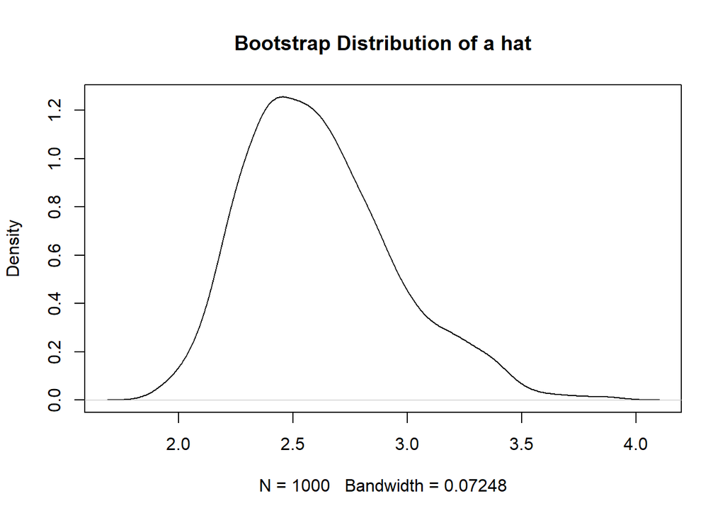

```r
# 1,000 bootstrap samples
B <- 1000
a_boot <- numeric(B)
b_boot <- numeric(B)

set.seed(123)

for(i in 1:B){
  sample_storage <- sample(storage, replace=TRUE)

  fit_boot <- optim(c(a_hat,b_hat), function(par){
    a <- par[1]; b <- par[2]
    if(a<=0 || b<=0) return(Inf)

    # Log-likelihood function
    ll <- length(sample_storage)*log(a)+length(sample_storage)*log(b)+
      (a-1)*sum(log(sample_storage))+
      (b-1)*sum(log(1-sample_storage^a))

    return(-ll)
  }, method="L-BFGS-B", lower=c(0.001,0.001))

  a_boot[i] <- fit_boot$par[1]
  b_boot[i] <- fit_boot$par[2]
}

# Kernel density plots
plot(density(a_boot), main="Bootstrap Distribution of a hat")
```

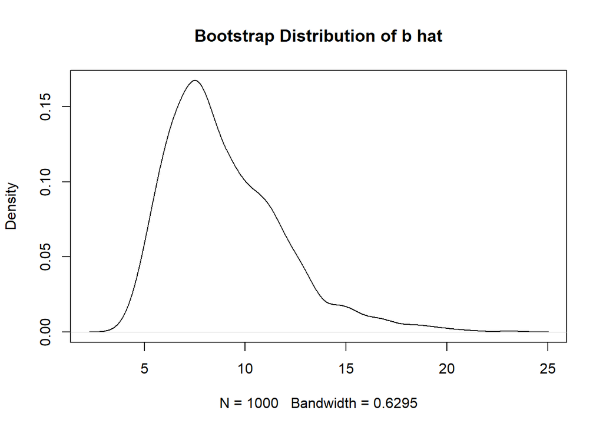

```r
plot(density(b_boot), main="Bootstrap Distribution of b hat")
```

The bootstrap distribution for $\hat{a}$ appears to be skewed to the right. This skew is quite noticeable and apparent in the plot. The mean of $\hat{a}$ appears to be right around the estimated value of 2.53 that was found in part B1.

(2). Construct both the $95\%$ **bootstrap confidence interval** and the **Wald confidence interval** for $b$. Do these intervals agree with the results obtained in **Problem B2**? [*Compute the standard error of $\hat{b}$ using the observed Fisher information matrix, i.e., the inverse of the negative Hessian obtained from optim()*]

Next, I will construct the 95% bootstrap confidence interval and the Wald confidence interval for $b$. As was found in part B2, the conclusion was to reject the null hypothesis that $b=1$. So, it would be expected that both of these confidence intervals for $b$ do not include 1.

```r
# Bootstrap CI
quantile(b_boot, c(0.025,0.975))
```

```
     2.5%     97.5%
 5.126594 16.296089
```

```r
# Wald CI using Hessian
H <- fit$hessian
Var <- solve(H)
se_b <- sqrt(Var[2,2])

wald_ci <- c(b_hat - 1.96*se_b, b_hat + 1.96*se_b)
wald_ci
```

```
[1]  3.48395 12.28284
```

The 95% bootstrap confidence interval for $b$ is [5.13, 16.30]. The 95% Wald confidence interval for $b$ is [3.48, 12.28]. Both of these confidence intervals do not include 1, so the same conclusion to reject the null hypothesis that $b=1$ would be reached from these two confidence intervals. Therefore, both confidence intervals match up with the results found previously in part B2.

(3). Based on the bootstrap sampling distributions from part (1) of this problem, assess whether the validity of the Wald confidence interval is supported.

In question 1 of B3, the sampling distribution for the $\hat{a}$ and $\hat{b}$ MLEs were plotted. So, the bootstrap distribution of $\hat{b}$ is skewed. It was found that these distributions were skewed to the right, and did not follow a Normal distribution. Therefore, the validity of the Wald confidence interval is questionable due to this lack of normality.

### **Problem B4**:

In the introduction to the working model for this exam, the Kumaraswamy distribution reduces to the uniform distribution on (0,1). In this problem, we perform a **likelihood ratio test** for the following hypothesis to assess whether the data come from the uniform distribution on (0,1):

$$H_0: a = 1\quad \& \quad b = 1\quad \text{ versus } \quad H_a: a \ne
1 \quad \text{or} \quad b \ne 1 \quad \text{or}\quad (a \ne 1 \quad
\& \quad b \ne 1).$$

Provide a practical interpretation of the above test result. [*Hint: $H_a$ basically says that there is no constraints for $a$ and $b$. Please review the lecture note for module 11 on the likelihood ratio test before coding.*]

Lastly, I will be testing whether or not the data follows a Uniform (0,1) distribution. In a uniform distribution $a=1$ and $b=1$. Previously, I tested for a power distribution where just $b =1$, but for a uniform distribution both parameters $a$ and $b$ equal 1. The alternative hypothesis will be that $a\neq1$ and $b\neq1$. In this case, the Kumaraswamy distribution would be the better choice, as both parameters significantly differ from 1 so the simpler uniform model would not adequately represent the data.

The hypotheses are as follows:

$H_0: a = 1\quad \& \quad b = 1$

$H_1: a \ne 1 \quad \text{or} \quad b \ne 1 \quad \text{or}\quad (a \ne 1 \quad \& \quad b \ne 1)$.

I will create an R function to tests these hypotheses.

```r
# Log-likelihood under full model
ll_full <- -fit$value

# Log-likelihood under H0 (Uniform)
ll_null <- 0

# Test statistic
LRT2 <- -2 * (ll_null - ll_full)

# p-value
p_value <- 1 - pchisq(LRT2, df = 2)

LRT2
```

```
[1] 49.12542
```

```r
p_value
```

```
[1] 2.150558e-11
```

The test statistic is 49.13 and the p-value is p < .001. Therefore, the conclusion would be the reject the null hypothesis and conclude that there is significant evidence that the data does not follow a Uniform distribution.

In the practical context of the data, this would mean that the water reservoirs do not have levels that are evenly distributed (uniform). Therefore, the Kumaraswamy distribution is a better representation of the flucation in these water reservoir levels and should be used.

**Note**: Please download the template and insert your work into it to complete the exam.